# Density_Project_Module

Abby Robinson

1/30/2023

# How do density dependent dynamics influence the efficacy of mimetic signaling?

## This module will walk you through conducting a robust statistical analysis of data collected at La Selva Biological Station during the summer of 2022.

## First Step: Make the Data

I’ve sent you an excel file to construct the initial data set from recorded attack photos. When you make these files, it is very important that you use the same format for naming all terms and variables. It is also very important to NOT include any spaces in the cells. Putting a space after a word doesn’t mean much in excel, but we are converting these files into CSV files and inputting them into R, and R does detects spaces, and will categorize terms that contain a space differently.

Given all the potential issues with this initial data writing process, it is important for us to have a way to check whether that data has been inputted without error. So, you will need to calculate, by hand, how many attacks we see on each facsimile type (iphiclus, serpa, junonia) for each experiment (Wk1: LD, Wk1: HD, Wk2: LD, Wk2: HD) on each day (1, 2, 3, 4). This will be your first step. After calculating these totals, we can decide whether to include attacks marked as “maybe” in our analysis. My initial plan is to not include these attacks, but if we have low attack rates, we might need to include them.

You will make write two, separate excel files. One will be written as “count” data and the other will be written as “binomial” data. In the count data set, you will input a total number of attacks on each facsimile type for each site. In the binomial data set, you will input attacks as 1’s and 0’s. binomial data is more informative, more robust, and gives us more flexibility with statistical analysis, but there is a chance that our data will be zero-inflated, which happens when an excessive number of zeros cause the data to be skewed and cause analyses with a binomial distribution to be uninformative. If this is the case, we will proceed with the count data. Therefore, you will make both types of datasets before we get started.

I’ve given you an example of how to write data from one observation event at one site in the excel. For the count data, you will write one line for each species in each site. For the binomial data, you will write one line for each individual facsimile in each site. You will also include the date that data were recorded so we can include this as a random effect in our model.

We also want to include “site” as a random effect variable in our analysis, so we need to write this variable in our data set in a way that accurately tells R which sites are different. Site 1 in the week 1 low density experiment is not the same as site 1 in the week 2 low density experiment, so we don’t want to give these two different locations the same name in our dataset.

#### Given that, you will record…

- Week 1: Low Density Sites 1-25 = sites 1-25 in dataset
- Week 1: High Density Sites 1-25 = sites 26-50 in dataset
- Week 2: Low Density Sites 1-25 = sites 51-75 in dataset
- Week 2: High Density Sites 1-25 = sites 76-100 in dataset

## Second Step: Connecting to GitHub

You’ll need to create a project in RStudio on your computer and link to to my GitHub repository for this project. You can find my GitHub repo [here](https://github.com/butterfliesrcool/Density_Dependent_Dynamics)

### To link a R Project to a GitHub Repo,

1. In RStudio, go to “file”, “new project”
2. Select “version control” and “git”
3. Input the URL for my repo (above), name your project, and chose where on your computer you want to store it
4. You can now create your own R Markdown file to begin writing your code!

If you have any issues connecting to GitHub or want a more detailed refresher, check out Dr. Chris Schmitt’s GitHub module [here](https://fuzzyatelin.github.io/bioanth-stats/module-02/module-02.html)

## Third Step: Initial Data Visualization

### What are the goals of this project?

we are testing the hypothesis that variation in the absolute density of Batesian models and their imperfect mimics impacts the rate of predation on artificial butterfly facsimiles using a paired experimental design (low vs. high density)

### Loading the data

At this point, you have used the final sorted attack photos to write two data sets: one with count data and another with binomial data. You should have also calculated, by hand, the attack totals on each day. Please compare those attack rates to the ones calculated below. If they do not match, you may need to check your excel file for spaces using the find and replace functions

Install the “Curl” Package and then load the package library using the code below

```r
library(curl)
```

Use the “curl” command to load the data into R using the data file link from the repo

```r
c <- curl("https://raw.githubusercontent.com/butterfliesrcool/Temporal_Dynamics/main/Quabbin_Mimic_Data.csv")
mimic <- read.csv(c, header = TRUE, sep = ",")
head(mimic)
```

```
##   treatment experiment.day field.site   species attacks field.day
## 1      four              1          1 limenitis       1         1
## 2      four              1          2 limenitis       0         1
## 3      four              1          3 limenitis       0         1
## 4      four              1          4 limenitis       0         1
## 5      four              1          5 limenitis       1         1
## 6      four              1          6 limenitis       1         2
```

Making sure R is “reading” the variables field.day, experiment.day, field.site, species, and treatment at factors. Attacks variable should be an integer value

```r
# make experimental.day variable factor
class(mimic$experiment.day)
```

```
## [1] "integer"
```

```r
mimic$experiment.day <- as.factor(mimic$experiment.day)
class(mimic$experiment.day)
```

```
## [1] "factor"
```

```r
# make field.day variable factor
class(mimic$field.day)
```

```
## [1] "integer"
```

```r
mimic$field.day <- as.factor(mimic$field.day)
class(mimic$field.day)
```

```
## [1] "factor"
```

```r
# make site variable factor
class(mimic$field.site)
```

```
## [1] "integer"
```

```r
mimic$field.site <- as.factor(mimic$field.site)
class(mimic$field.site)
```

```
## [1] "factor"
```

```r
# make sure attack variable is integer
class(mimic$attacks) # only thing that should be an integer
```

```
## [1] "integer"
```

```r
# make species variable factor
class(mimic$species)
```

```
## [1] "character"
```

```r
mimic$species <- as.factor(mimic$species)
class(mimic$species)
```

```
## [1] "factor"
```

```r
# make treatment variable factor
class(mimic$treatment)
```

```
## [1] "character"
```

```r
mimic$treatment <- as.factor(mimic$treatment)
class(mimic$treatment)
```

```
## [1] "factor"
```

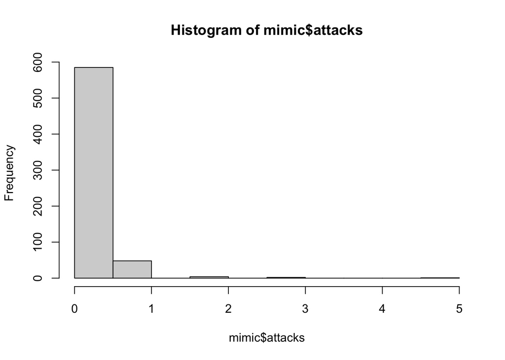

```r
# histogram of attacks
hist(mimic$attacks)  #concerns about zero inflation based on histogram?
```

```r
# check variance and mean to assess for over /  under - dispersion
var(mimic$attacks)
```

```
## [1] 0.1564725
```

```r
mean(mimic$attacks) # variance is greater than mean, which indicates that over-dispersion might be an issue
```

```
## [1] 0.1046875
```

```r
# summarizing attacks
aggregate(x= mimic$attacks, by= list(mimic$experiment.day, mimic$species), FUN=sum)
```

```
##   Group.1   Group.2  x
## 1       1   junonia 18
## 2       2   junonia  6
## 3       3   junonia  3
## 4       4   junonia  8
## 5       1 limenitis 14
## 6       2 limenitis  4
## 7       3 limenitis  8
## 8       4 limenitis  6
```

Do these numbers match yours? If so, we can move on!

## Fourth Step: Model Building

Install and load the lme4, glmmTMB, and performance packages

```r
library(lme4)
library("glmmTMB")
library(performance)
```

Here we start the process of building a generalized linear mixed model (GLMM). The model below was used to analyze the data from the quabbin reservoir. We will modify it to fit the data and research questions from Costa Rica. First, our response variable is “attacks”, when this data is recorded as counts (total number of attacks on each species), we can use the Poisson distribution (family=poisson). However, the assumptions of the Poisson distribution may not be met if our data is zero inflated. If this happened, we can try to adjust the model or use the negative binomial distribution instead.

the * in the model below indicates an interaction between variables. For example, (attacks ~ treatment + species) would tell you if attacks vary between different treatments and if attacks vary between species, independently. Alternatively, (attacks ~ treatment*species) would tell you if the total number of attacks varies across species within different treatments. We will need to figure out the right coding syntax to address our hypothesis from the Costa Rica project.

The variables discussed above are fixed variables because they represent specific treatments that we employed. The location of field sites and the day that we collected data are random effect variables because they are things that could influence our results, but were not specifically controled in the experiment.

```r
mod1 <- glmmTMB(attacks ~ experiment.day*species + treatment*species + (1|field.site) + (1|field.day), data=mimic,ziformula=~1,family=poisson)
summary(mod1)
```

```
##  Family: poisson  ( log )
## Formula:
## attacks ~ experiment.day * species + treatment * species + (1 |
##     field.site) + (1 | field.day)
## Zero inflation:           ~1
## Data: mimic
##
##      AIC      BIC   logLik deviance df.resid
##    438.8    514.7   -202.4    404.8      623
##
## Random effects:
##
## Conditional model:
##  Groups     Name        Variance  Std.Dev.
##  field.site (Intercept) 7.999e-01 0.8943948
##  field.day  (Intercept) 1.627e-08 0.0001276
## Number of obs: 640, groups:  field.site, 80; field.day, 7
##
## Conditional model:
##                                   Estimate Std. Error z value Pr(>|z|)
## (Intercept)                      -1.816995   0.606125  -2.998  0.00272 **
## experiment.day2                  -1.081559   0.488049  -2.216  0.02669 *
## experiment.day3                  -1.767773   0.637513  -2.773  0.00556 **
## experiment.day4                  -0.784044   0.446136  -1.757  0.07885 .
## specieslimenitis                  0.306970   0.567413   0.541  0.58851
## treatmentone                      0.031130   0.633370   0.049  0.96080
## treatmenttwo                     -0.467144   0.677633  -0.689  0.49059
## treatmentzero                     0.779612   0.570916   1.365  0.17208
## experiment.day2:specieslimenitis -0.126617   0.759938  -0.167  0.86767
## experiment.day3:specieslimenitis  1.200739   0.783425   1.533  0.12536
## experiment.day4:specieslimenitis -0.067434   0.668981  -0.101  0.91971
## specieslimenitis:treatmentone    -0.466237   0.740697  -0.629  0.52905
## specieslimenitis:treatmenttwo     0.007677   0.729037   0.011  0.99160
## specieslimenitis:treatmentzero   -1.795440   0.763392  -2.352  0.01868 *
## ---
## Signif. codes:  0 '***' 0.001 '**' 0.01 '*' 0.05 '.' 0.1 ' ' 1
##
## Zero-inflation model:
##             Estimate Std. Error z value Pr(>|z|)
## (Intercept)   -1.215      1.447   -0.84    0.401
```

```r
check_singularity(mod1)
```

```
## [1] TRUE
```

```r
# singularity issues, likely due to the field.day random effect variable
```

We will need to check this model for singularity issues, convergence issues, error messages, residuals, and assumptions fit

Check residuals with “DHARMa” package

```r
library(DHARMa)
```

We used the “DHARMa” package to check residuals and model assumptions

```r
vignette("DHARMa", package="DHARMa") ### Useful information for checking residuals/ model assumptions
```

```
## starting httpd help server ... done
```

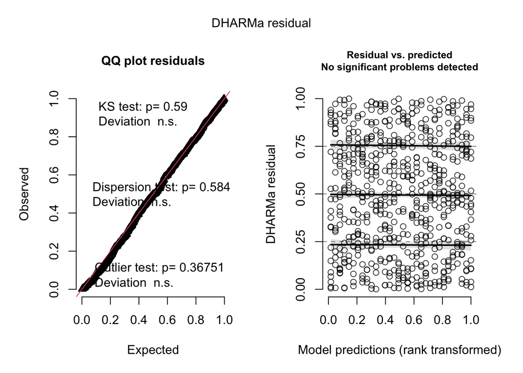

```r
mod1simulation <- simulateResiduals(fittedModel = mod1, plot = T)
```

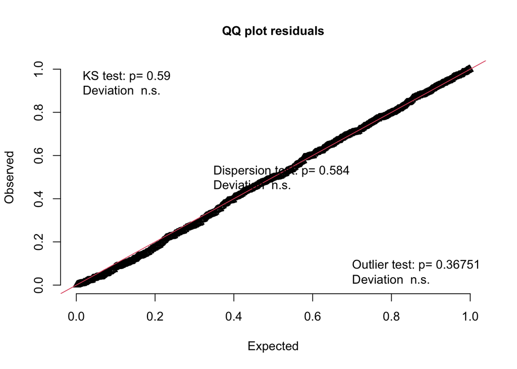

```
##
##  One-sample Kolmogorov-Smirnov test
##
## data:  simulationOutput$scaledResiduals
## D = 0.030523, p-value = 0.59
## alternative hypothesis: two-sided
```

```r
testUniformity(mod1simulation)
```

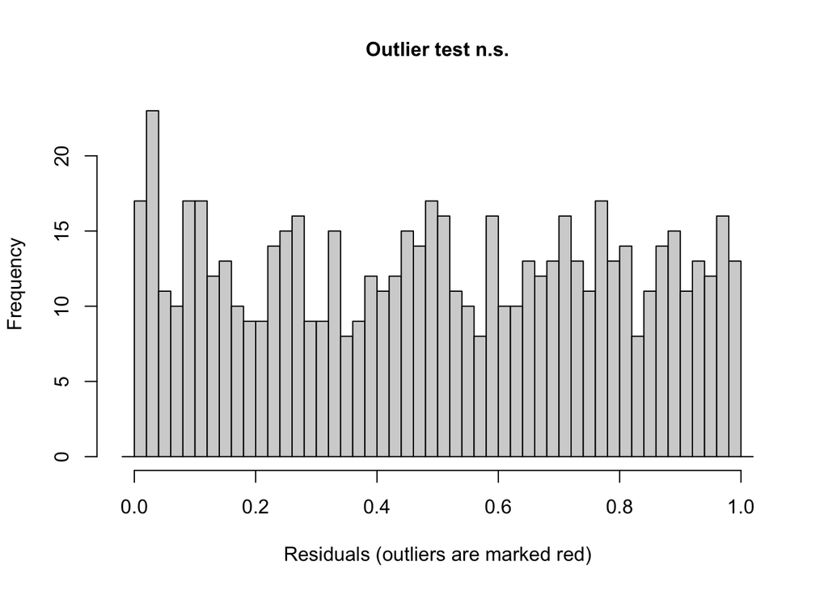

```
##
##  DHARMa outlier test based on exact binomial test with approximate
##  expectations
##
## data:  mod1simulation
## outliers at both margin(s) = 7, observations = 640, p-value = 0.3675
## alternative hypothesis: true probability of success is not equal to 0.007968127
## 95 percent confidence interval:
##  0.004408436 0.022404927
## sample estimates:
## frequency of outliers (expected: 0.00796812749003984 )
##                                              0.0109375
```

```r
testOutliers(mod1simulation)
```

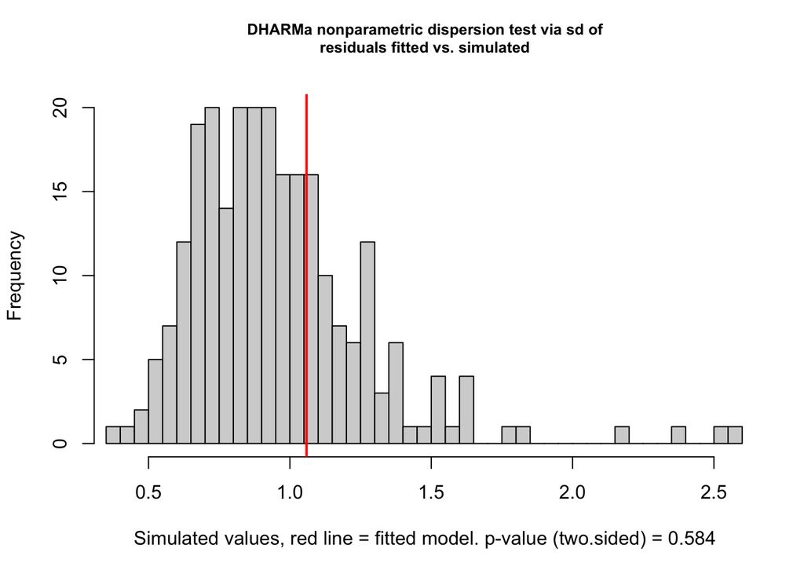

```
##
##  DHARMa nonparametric dispersion test via sd of residuals fitted vs.
##  simulated
##
## data:  simulationOutput
## dispersion = 1.1014, p-value = 0.584
## alternative hypothesis: two.sided
```

```r
testDispersion(mod1simulation)
```

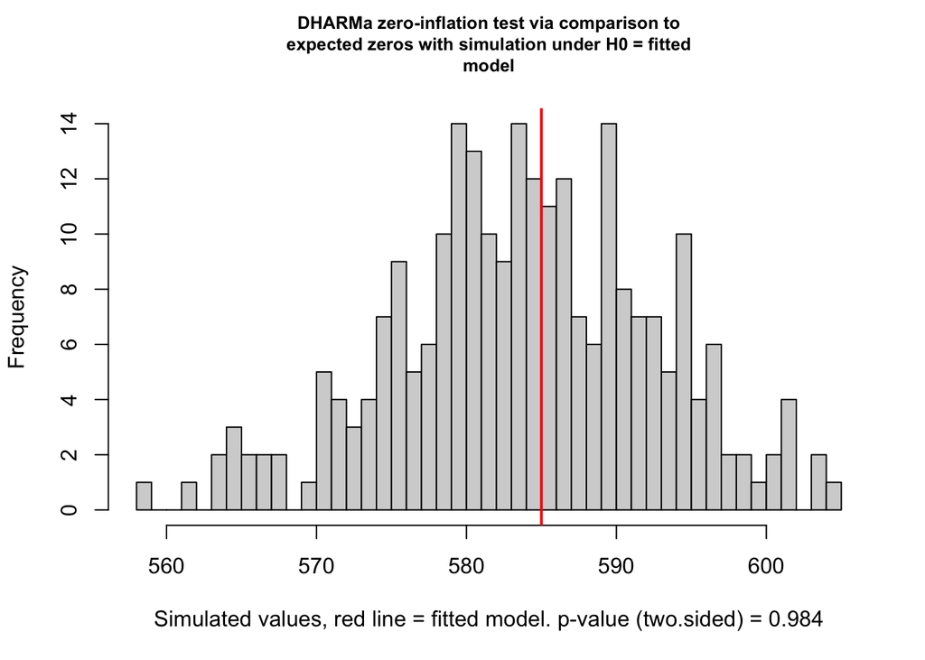

```
##
##  DHARMa zero-inflation test via comparison to expected zeros with
##  simulation under H0 = fitted model
##
## data:  simulationOutput
## ratioObsSim = 1.0011, p-value = 0.984
## alternative hypothesis: two.sided
```

```r
testZeroInflation(mod1simulation)
```

## Post Hoc Pairwise Comparison

```r
library(emmeans)
```

For the Costa Rica project, we want to compare attacks on iphiclus and serpa directly to attacks on junonia to account for variation in the number of facsimiles in the low density and high density experiments. To do this, we will perform a pairwise post hoc test comparing species within the different treatments

```r
post.hoc1 <- emmeans(mod1, pairwise ~ species|treatment)
#there is a significant difference in the attack rates on junonia and limenitis only in the zero week treatment (simultaneous presentation)
post.hoc1
```

```
## $emmeans
## treatment = four:
##  species   emmean    SE  df lower.CL upper.CL
##  junonia    -2.73 0.603 623    -3.91   -1.541
##  limenitis  -2.17 0.555 623    -3.26   -1.076
##
## treatment = one:
##  species   emmean    SE  df lower.CL upper.CL
##  junonia    -2.69 0.617 623    -3.91   -1.483
##  limenitis  -2.60 0.600 623    -3.78   -1.423
##
## treatment = two:
##  species   emmean    SE  df lower.CL upper.CL
##  junonia    -3.19 0.700 623    -4.57   -1.819
##  limenitis  -2.63 0.620 623    -3.84   -1.408
##
## treatment = zero:
##  species   emmean    SE  df lower.CL upper.CL
##  junonia    -1.95 0.551 623    -3.03   -0.863
##  limenitis  -3.18 0.685 623    -4.53   -1.837
##
## Results are averaged over the levels of: experiment.day
## Results are given on the log (not the response) scale.
## Confidence level used: 0.95
##
## $contrasts
## treatment = four:
##  contrast            estimate    SE  df t.ratio p.value
##  junonia - limenitis  -0.5586 0.518 623  -1.079  0.2810
##
## treatment = one:
##  contrast            estimate    SE  df t.ratio p.value
##  junonia - limenitis  -0.0924 0.566 623  -0.163  0.8704
##
## treatment = two:
##  contrast            estimate    SE  df t.ratio p.value
##  junonia - limenitis  -0.5663 0.555 623  -1.020  0.3082
##
## treatment = zero:
##  contrast            estimate    SE  df t.ratio p.value
##  junonia - limenitis   1.2368 0.594 623   2.081  0.0378
##
## Results are averaged over the levels of: experiment.day
## Results are given on the log (not the response) scale.
```

## Survival Analysis

Butterfly model survivorship across the four day experimental period will be analyzed using a Cox propportional-hazards regression model (“survival” package) with post hoc Wald tests between phenotype pairs.

```r
library(survival)
library(survminer)
```

Use the “curl” command to load the binomial data into R for the survival analysis

```r
b <- curl("https://raw.githubusercontent.com/butterfliesrcool/Density_Dependent_Dynamics/main/density_dependence_binomial.csv")
binomial <- read.csv(b, header = TRUE, sep = ",", na.strings=c("","NA"))
binomial[is.na(binomial)] <- "N"
head(binomial)
```

```
##   week  experiment experiment_day site field_day  species fac_number confidence
## 1    1 low_density              1    1   5/28/22 iphiclus          1          N
## 2    1 low_density              1    1   5/28/22 iphiclus          2          N
## 3    1 low_density              1    1   5/28/22 iphiclus          3          N
## 4    1 low_density              1    1   5/28/22 iphiclus          4          N
## 5    1 low_density              1    1   5/28/22 iphiclus          5          N
## 6    1 low_density              1    1   5/28/22 iphiclus          6          N
##   attacks
## 1       0
## 2       0
## 3       0
## 4       0
## 5       0
## 6       0
```

```r
Wk1 <- subset(binomial, week == "1")
Wk1LD <- subset(Wk1, experiment == "low_density")
Wk1LD_model <- survfit(Surv(experiment_day, experiment_day+1, attacks) ~ species, data=Wk1LD)
Wk1LD_model
```

```
## Call: survfit(formula = Surv(experiment_day, experiment_day + 1, attacks) ~
##     species, data = Wk1LD)
##
##                  records   n events median 0.95LCL 0.95UCL
## species=iphiclus    2000 500     14     NA      NA      NA
## species=junonia     2000 500     21     NA      NA      NA
## species=serpa       2000 500     25     NA      NA      NA
```

```r
summary(Wk1LD_model)
```

```
## Call: survfit(formula = Surv(experiment_day, experiment_day + 1, attacks) ~
##     species, data = Wk1LD)
##
##                 species=iphiclus
##  time n.risk n.event survival std.err lower 95% CI upper 95% CI
##     2    500       4    0.992 0.00398        0.984        1.000
##     3    500       5    0.982 0.00592        0.971        0.994
##     4    500       3    0.976 0.00679        0.963        0.990
##     5    500       2    0.972 0.00730        0.958        0.987
##
##                 species=junonia
##  time n.risk n.event survival std.err lower 95% CI upper 95% CI
##     2    500       7    0.986 0.00525        0.976        0.996
##     3    500       3    0.980 0.00623        0.968        0.992
##     4    500       5    0.970 0.00756        0.956        0.985
##     5    500       6    0.959 0.00884        0.941        0.976
##
##                 species=serpa
##  time n.risk n.event survival std.err lower 95% CI upper 95% CI
##     2    500       8    0.984 0.00561        0.973        0.995
##     3    500       6    0.972 0.00733        0.958        0.987
##     4    500       6    0.961 0.00865        0.944        0.978
##     5    500       5    0.951 0.00957        0.932        0.970
```

```r
# SUSAN'S DATA
p <- curl("https://raw.githubusercontent.com/butterfliesrcool/BI588_Replication_Assignment/main/Adelpha2016_binomial.csv")
binomial.data  <- read.csv(p, header = TRUE, sep = ",", stringsAsFactors = FALSE)
```

```r
coxph(Surv(experiment_day, experiment_day+1, attacks) ~ species, data=Wk1LD)
```

```
## Call:
## coxph(formula = Surv(experiment_day, experiment_day + 1, attacks) ~
##     species, data = Wk1LD)
##
##                  coef exp(coef) se(coef)     z     p
## speciesjunonia 0.4072    1.5026   0.3450 1.180 0.238
## speciesserpa   0.5825    1.7905   0.3338 1.745 0.081
##
## Likelihood ratio test=3.25  on 2 df, p=0.1969
## n= 6000, number of events= 60
```

Subset specific species pairwise comparisons from “binomial.data”

```r
ei <- subset(binomial.data, species %in% c("evarete", "iphiclus"), drop = FALSE)
si <- subset(binomial.data, species %in% c("serpa", "iphiclus"), drop = FALSE)
li <- subset(binomial.data, species %in% c("leucopthalma", "iphiclus"), drop = FALSE)
le <- subset(binomial.data, species %in% c("leucopthalma", "evarete"), drop = FALSE)
ls <- subset(binomial.data, species %in% c("leucopthalma", "serpa"), drop = FALSE)
es <- subset(binomial.data, species %in% c("evarete", "serpa"), drop = FALSE)
```

evarete-iphiclus comparison (significant)

```r
coxph(Surv(day, day+1, attacks) ~ species, data=ei)
```

```
## Call:
## coxph(formula = Surv(day, day + 1, attacks) ~ species, data = ei)
##
##                    coef exp(coef) se(coef)      z      p
## speciesiphiclus -0.5542    0.5745   0.2293 -2.417 0.0156
##
## Likelihood ratio test=6.07  on 1 df, p=0.01377
## n= 4000, number of events= 82
```

serpa-iphiclus comparison (significant)

```r
coxph(Surv(day, day+1, attacks) ~ species, data=si)
```

```
## Call:
## coxph(formula = Surv(day, day + 1, attacks) ~ species, data = si)
##
##                coef exp(coef) se(coef)     z       p
## speciesserpa 0.6315    1.8804   0.2263 2.791 0.00525
##
## Likelihood ratio test=8.18  on 1 df, p=0.004245
## n= 4000, number of events= 86
```

leucopthalma-iphiclus comparison (significant)

```r
coxph(Surv(day, day+1, attacks) ~ species, data=li)
```

```
## Call:
## coxph(formula = Surv(day, day + 1, attacks) ~ species, data = li)
##
##                       coef exp(coef) se(coef)     z      p
## speciesleucopthalma 0.5350    1.7075   0.2301 2.325 0.0201
##
## Likelihood ratio test=5.6  on 1 df, p=0.01796
## n= 4000, number of events= 81
```

leucopthalma-evarete comparison (not significant)

```r
coxph(Surv(day, day+1, attacks) ~ species, data=le)
```

```
## Call:
## coxph(formula = Surv(day, day + 1, attacks) ~ species, data = le)
##
##                         coef exp(coef) se(coef)      z     p
## speciesleucopthalma -0.01927   0.98091  0.19708 -0.098 0.922
##
## Likelihood ratio test=0.01  on 1 df, p=0.9221
## n= 4000, number of events= 103
```

leucopthalma-serpa comparison (not significant)

```r
coxph(Surv(day, day+1, attacks) ~ species, data=ls)
```

```
## Call:
## coxph(formula = Surv(day, day + 1, attacks) ~ species, data = ls)
##
##                 coef exp(coef) se(coef)     z    p
## speciesserpa 0.09609   1.10086  0.19356 0.496 0.62
##
## Likelihood ratio test=0.25  on 1 df, p=0.6194
## n= 4000, number of events= 107
```

evarete-serpa comparison (not significant)

```r
coxph(Surv(day, day+1, attacks) ~ species, data=es)
```

```
## Call:
## coxph(formula = Surv(day, day + 1, attacks) ~ species, data = es)
##
##                 coef exp(coef) se(coef)     z    p
## speciesserpa 0.07678   1.07981  0.19258 0.399 0.69
##
## Likelihood ratio test=0.16  on 1 df, p=0.69
## n= 4000, number of events= 108
```

While Finkbeiner did not report using the pairwise_survdiff() function in her publication, this is another possibly easier way to generate pairwise comparisons in the survival differences between species.

```r
survdiff(Surv(day, attacks) ~ species, data=binomial.data)
```

```
## Call:
## survdiff(formula = Surv(day, attacks) ~ species, data = binomial.data)
##
##                         N Observed Expected (O-E)^2/E (O-E)^2/V
## species=evarete      2000       52     47.2     0.478     0.643
## species=iphiclus     2000       30     47.2     6.298     8.479
## species=leucopthalma 2000       51     47.2     0.298     0.401
## species=serpa        2000       56     47.2     1.620     2.182
##
##  Chisq= 8.8  on 3 degrees of freedom, p= 0.03
```

```r
pairwise_survdiff(Surv(day, attacks) ~ species, p.adjust.method = "BH",
     data = binomial.data)
```

```
##
##  Pairwise comparisons using Log-Rank test
##
## data:  binomial.data and species
##
##              evarete iphiclus leucopthalma
## iphiclus     0.038   -        -
## leucopthalma 0.921   0.038    -
## serpa        0.839   0.029    0.839
##
## P value adjustment method: BH
```

```r
library(ggplot2)
```

We can plot the survfit model generated above in baseR using the function plot()

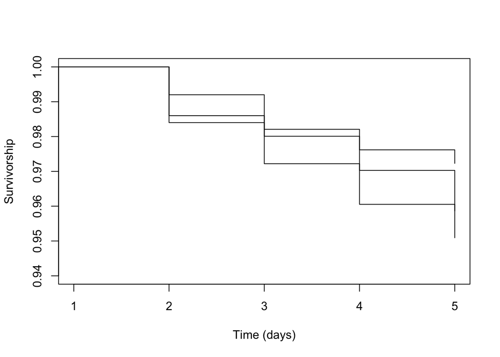

```r
plot(Wk1LD_model, xlab="Time (days)",
           ylab="Survivorship",
           ylim = c(0.94, 1.0),
           xlim = c(1, 5))
```

## Summary

This is the analysis you will have to modify and apply to the Costa Rica Project